# Practical machine learning project

mohie eldin

December 2, 2019

## Setup

### Load packages and data

```r
library(ggplot2)
library(caret)
library(rpart)
library(randomForest)
library(gbm)
library(mlbench)
library(e1071)
library(ISLR)
library(ada)
```

## Data description

The dataset information from accelerometers on the belt, forearm, arm, and dumbell of 6 participants to predict the manner in which they did the exercis, hence we can conclude how good a participant did the excersise.

#### generabizability :

The data is `randomly` sampled and it’s big enough (19000 observations) so the generabizability princple is achieved.

#### Removing columns with a lot of null/empty values, columns that are highly correlated and also the first 7 variables are not useful information.

```r
training <- read.csv("E:/Coursera data science specialization/7. Practical machine learning/project/pml-training.csv")
testing <- read.csv("E:/Coursera data science specialization/7. Practical machine learning/project/pml-testing.csv")


training <- training[,-which(colMeans(is.na(training) | training == "" ) > 0.7)]
testing <- testing[,-which(colMeans(is.na(testing) | testing == "")  > 0.7)]
training <- training[,-c(1:7)]
testing <- testing[,-c(1:7)]
# checking weather there are factor variables or not
which(sapply(training , is.factor))
```

```
## classe
##     53
```

#### We don’t have any factor variable except our target variable now so i can test the correlation on all the variables.

```r
corMat <- cor(subset(training , select = -classe ))
highlyCor <- findCorrelation(corMat , cutoff = 0.90)
print(highlyCor)
```

```
## [1] 10  1  9  8 31 33 18
```

```r
#removing the highly correlated variavbles :
training <- training[,-highlyCor]
testing <- testing[,-highlyCor]
dim(training)
```

```
## [1] 19622    46
```

```r
dim(testing)
```

```
## [1] 20 46
```

## Research question

Given some informations from accelometers what is the manner the participant used ? the model should classify a manner from 5 different types.

## target variable representation

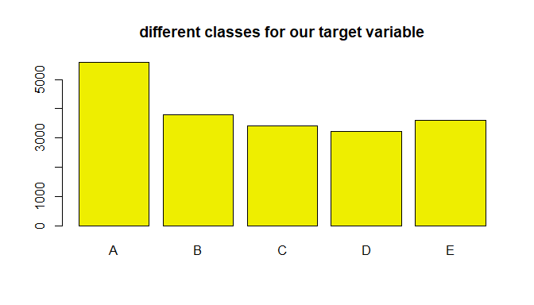

```r
plot(training$classe , main = "different classes for our target variable" , col = "yellow2")
```

## Preparing for building a model

#### I will split the training data into training and validation sets in order to see the performanc of the different models using the validation set.

```r
inTrain <- createDataPartition(y = training$classe , p = 0.7 , list = FALSE)
training <- training[inTrain,]
validation <- training[-inTrain,] #for testing models performance
```

#### Constuct the control for the models, i will use repreated cross validation technique with 5 folds and 5 repeats with random search to increase speed of the models.

```r
control <- trainControl(method = "repeatedcv" , number = 5 ,  repeats = 5, search = "random" )
seed <- 1
accuracy <- function(predictions , truth)
{
  sum(predictions == truth)/length(truth)
}
```